# Replication of ‘Generalized perceptual adaptation to second-language speech: Variability, similarity, and intelligibility’ by Bradlow, Bassard, & Paller (2023, J. Acoust. Soc. Am.)

[Nathan Roll] (nroll@stanford.edu)

May 02, 2025

## Introduction

This study is a partial replication of Bradlow, Bassard, and Paller’s (2023) investigation of perceptual adaptation to second-language (L2) speech. The original study examined the conditions that facilitate or constrain perceptual adaptation to L2 speech, with a focus on how variability in training exposure affects generalization of this adaptation. The authors tested whether high-variability (i.e., multiple-talker) training is necessary for cross-talker generalization or whether low-variability (i.e., single-talker) training can be sufficient for such generalization.

This replication focuses specifically on the training phase of the original study. I aim to test the prediction that some single-talker training conditions can lead to significant improvement in L2 speech recognition, suggesting that high-variability exposure is not necessary for perceptual adaptation. Furthermore, I will examine whether training phase intelligibility plays a crucial role in perceptual adaptation to L2 speech, as suggested by the original study’s post-hoc analysis.

## Methods

### Power Analysis

The original study found various effect sizes across different training conditions. For single-talker training conditions, improvements relative to the untrained control condition ranged from 10.2% (FAR training with BRP test talker, p < 0.003) to non-significant negative effects (-4.6% for TUR training with FAR test talker).

```r
# Load required packages
library(pwr)
library(tidyverse)
library(knitr)

# Convert percentage improvements to Cohen's d
# Based on original study's significant effects
# We're using an estimated pooled SD of 0.15 based on the reported SEs in the original study
calculate_d <- function(percent_improvement, pooled_sd = 0.15) {
  # Convert percentage to proportion
  prop_improvement <- percent_improvement / 100
  # Calculate Cohen's d
  d <- prop_improvement / pooled_sd
  return(d)
}

# Effect sizes from original study (significant results)
effects <- tibble(
  condition = c("FAR-BRP", "SPA-BRP", "BRP-BRP", "FAR-FAR", "FAR-SPA", "FAR-TUR"),
  percent_improvement = c(10.2, 6.8, 5.9, 5.6, 5.5, 5.4),
  cohens_d = calculate_d(percent_improvement)
)

# Calculate required sample sizes for different power levels
power_analysis <- effects %>%
  mutate(
    n_80_power = map_dbl(cohens_d, ~pwr.t.test(d = ., power = 0.8, sig.level = 0.05, type = "two.sample")$n),
    n_90_power = map_dbl(cohens_d, ~pwr.t.test(d = ., power = 0.9, sig.level = 0.05, type = "two.sample")$n),
    n_95_power = map_dbl(cohens_d, ~pwr.t.test(d = ., power = 0.95, sig.level = 0.05, type = "two.sample")$n)
  ) %>%
  mutate(across(starts_with("n_"), ceiling))

# Display the power analysis results
kable(power_analysis,
      col.names = c("Condition", "% Improvement", "Cohen's d",
                   "N (80% power)", "N (90% power)", "N (95% power)"),
      digits = c(0, 1, 2, 0, 0, 0))
```

| Condition | % Improvement | Cohen’s d | N (80% power) | N (90% power) | N (95% power) |
| --- | --- | --- | --- | --- | --- |
| FAR-BRP | 10.2 | 0.68 | 35 | 47 | 58 |
| SPA-BRP | 6.8 | 0.45 | 78 | 104 | 128 |
| BRP-BRP | 5.9 | 0.39 | 103 | 137 | 169 |
| FAR-FAR | 5.6 | 0.37 | 114 | 152 | 188 |
| FAR-SPA | 5.5 | 0.37 | 118 | 158 | 195 |
| FAR-TUR | 5.4 | 0.36 | 123 | 164 | 202 |

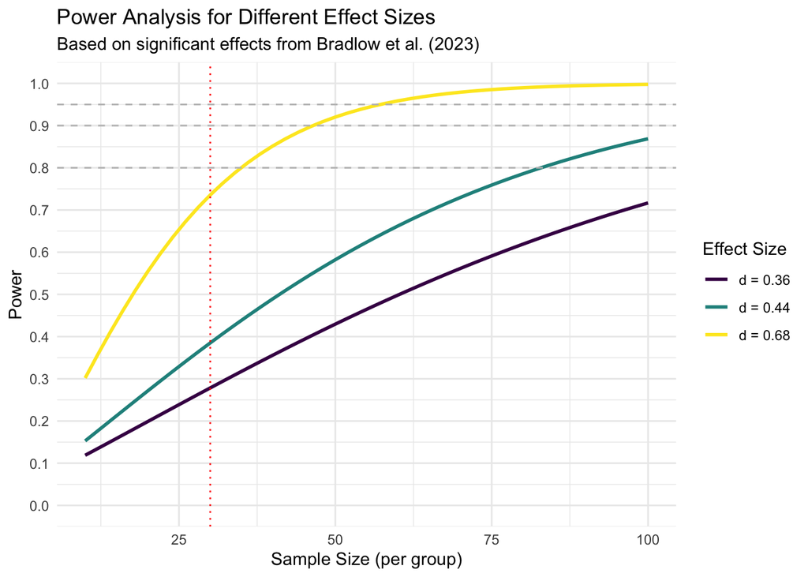

```r
# Calculate average sample sizes
avg_n_80 <- ceiling(mean(power_analysis$n_80_power))
avg_n_90 <- ceiling(mean(power_analysis$n_90_power))
avg_n_95 <- ceiling(mean(power_analysis$n_95_power))

# Create power curve plotting data manually to avoid warnings
# For minimum, mean, and maximum effect sizes
d_values <- c(min(effects$cohens_d), mean(effects$cohens_d), max(effects$cohens_d))
n_values <- seq(10, 100, by = 2)

# Create an empty data frame to store results
power_curve_data <- data.frame()

# Calculate power for each combination of d and n
for(d in d_values) {
  for(n in n_values) {
    # Need to ensure n is at least 2 for pwr.t.test to work
    if(n >= 2) {
      result <- pwr.t.test(n = n, d = d, sig.level = 0.05, type = "two.sample")
      power_curve_data <- rbind(power_curve_data,
                                data.frame(d = d, n = n, power = result$power))
    }
  }
}

# Create labels for the plot
d_labels <- sprintf("d = %.2f", d_values)
names(d_labels) <- as.character(d_values)

# Create the power curve plot
ggplot(power_curve_data, aes(x = n, y = power, color = factor(d))) +
  geom_line(linewidth = 1) +
  geom_hline(yintercept = c(0.8, 0.9, 0.95), linetype = "dashed", color = "gray") +
  scale_y_continuous(breaks = seq(0, 1, 0.1), limits = c(0, 1)) +
  scale_color_viridis_d(name = "Effect Size", labels = d_labels) +
  labs(x = "Sample Size (per group)", y = "Power",
       title = "Power Analysis for Different Effect Sizes",
       subtitle = "Based on significant effects from Bradlow et al. (2023)") +
  theme_minimal() +
  geom_vline(xintercept = 30, linetype = "dotted", color = "red")
```

```r
# Annotate power at n=30 for average effect size
avg_effect <- mean(effects$cohens_d)
power_at_30 <- pwr.t.test(n = 30, d = avg_effect, sig.level = 0.05, type = "two.sample")$power
cat(sprintf("Power at n=30 for average effect size (d=%.2f): %.1f%%\n",
            avg_effect, power_at_30*100))
```

```
## Power at n=30 for average effect size (d=0.44): 38.5%
```